# Cognitive Impact of Music

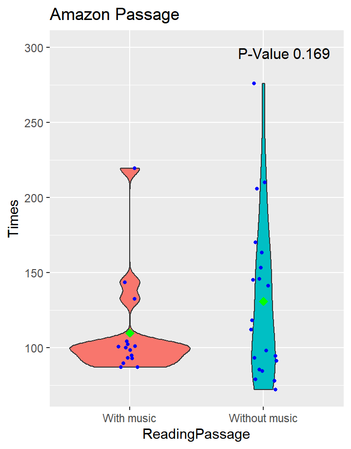

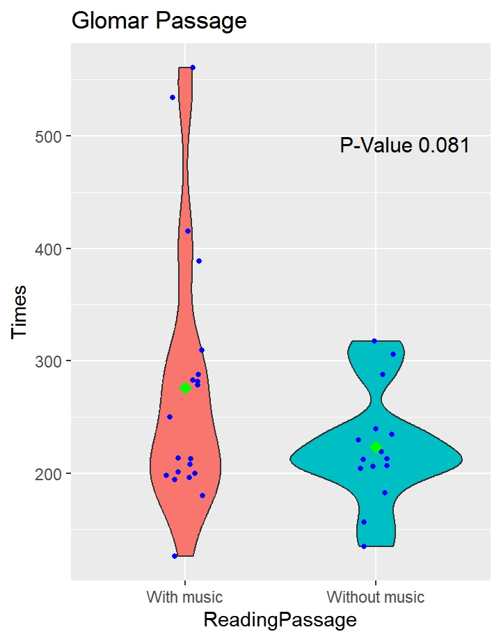

[figure not shown]

[figure not shown]

[figure not shown]

[figure not shown]

[figure not shown]

[figure not shown]

# Introduction

## Value Boxes

### Participants

50

### Didnt care

35

### Audiophiles

22

### Non

13

### Effected

32

### The Study

The objective of this study was to explore the impact of music on participants’ comprehension and retention of passages during reading. Two distinct passages, varying in difficulty levels, were presented to participants under two conditions: one with accompanying music and the other in silence. Post-reading, participants were promptly assessed through a set of questions related to the passages.

We tried to have a diverse participant pool, encompassing individuals with varied study backgrounds and age groups. This inclusivity aimed to capture insights from those who both regularly and infrequently listen to music while reading or studying. The study sought to discern whether participants, who typically refrain from incorporating music into their study routine, encounter difficulties in focus, or conversely, whether music enhances their cognitive processes during reading. This multifaceted approach allows us to explore the potential benefits or challenges associated with integrating music into the reading environment across different demographic groups.

### Our Hypothesis

Our working hypothesis is that the presence of music poses a greater challenge to concentration during more complex tasks, with minimal to no discernible impact on simpler ones. We anticipate observing negligible differences in performance metrics for the easier passage when comparing the conditions with and without music.

In contrast, we hypothesize a significant divergence in these metrics when participants engage with the more challenging passage, expecting a noticeable impact on concentration and comprehension. This hypothesis is grounded in the assumption that cognitive demands associated with difficult tasks may be more susceptible to external factors such as auditory stimuli.

### Playlist

| Song | Artist |
| --- | --- |
| As it was | Harry Styles |
| Drivers License | Olivia Rodrigo |
| Flowers | Miley Cyrus |
| You are the reason | Calum Scott |
| Thank U Next | Ariana Grande |

### Data cleaning

In order to get the best results, we had to clean out some of the responses filled in the survey. We started by clearing out any names which were not “anonymous”, and also cleared out responses filled in before 2024-01-15 in order to exclude our test responses from the results. Survey durations outside the range of 360 to 1800 seconds were filtered out. Columns containing time-related data were converted to numeric format with non-numeric entries replaced by NaN, and two new data frames are created by filtering the original data frame based on specific conditions. The purpose of this is to separate the data into two groups based on values of time taken to answer a question with music.

# Experiment Design

### The survey

The survey begins by collecting fundamental user information, including their age group and employment status. Subsequently, participants encounter the first passage, with the presence or absence of background music randomly assigned. After reading the initial passage under the specified condition, respondents are prompted to answer questions related to that passage.

Following this, participants proceed to the second passage, experiencing the opposite music condition from the first. For instance, if music accompanied the reading of the first passage, the second passage is read without music, and vice versa. Again, participants respond to questions pertaining to the second passage.

In addition to passage-specific questions, the survey delves into participants’ backgrounds, incorporating questions (stated below) designed to provide insights into potential influencing factors on the survey results. Through these questions we aim to enhance our understanding of how individual characteristics might correlate with the participants’ responses.

1. What effect did the music have on your reading performance?
1. music made it more difficult to read
2. there was no difference
3. the music made it easier to read
2. Do you usually listen to music while reading or studying/working?
1. Yes
2. No
3. What is your level of proficiency in English?
1. Elementary proficiency
2. Limited working proficiency
3. Professional working proficiency
4. Full professional proficiency/Native
4. What region are you from?
1. Europe
2. Asia
3. North america
4. Other

[figure not shown]

# Time with vs without music

### Passage 1

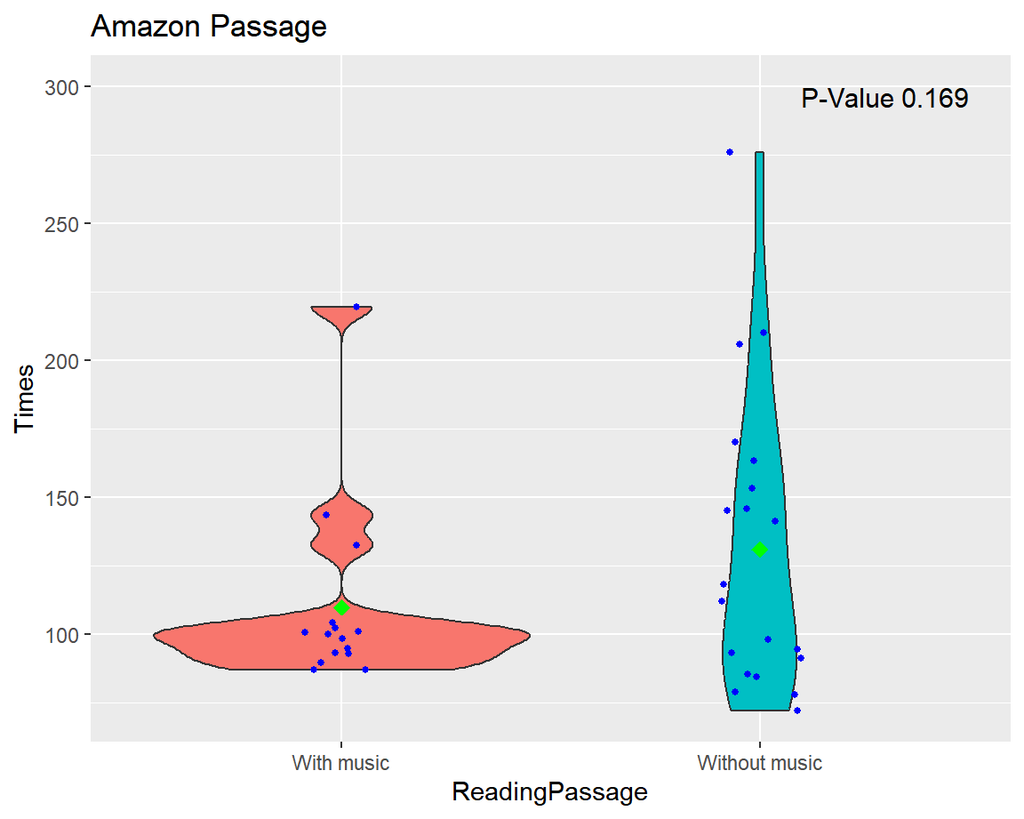

### Passage 2

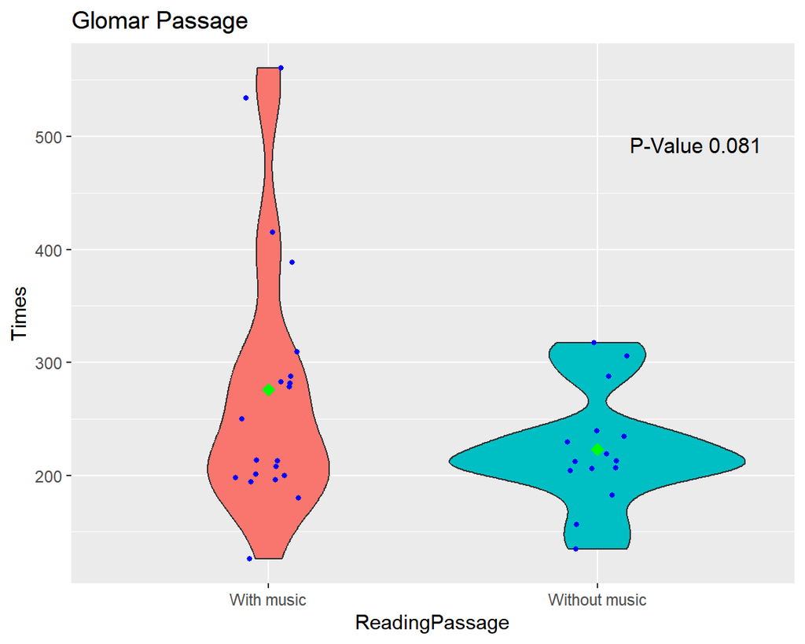

In examining the impact of background music on reading times for passages of varying difficulty levels, intriguing patterns emerged. For the challenging passage, participants ended up spending less time without music, suggesting a potential efficiency in navigating the complexities of the text. However, when music accompanied the difficult passage, the average reading time saw a notable increase, indicating that the presence of music might pose a challenge or distraction during the comprehension of more intricate content.

# Time vs Accuracy

### Passage 1 with Music

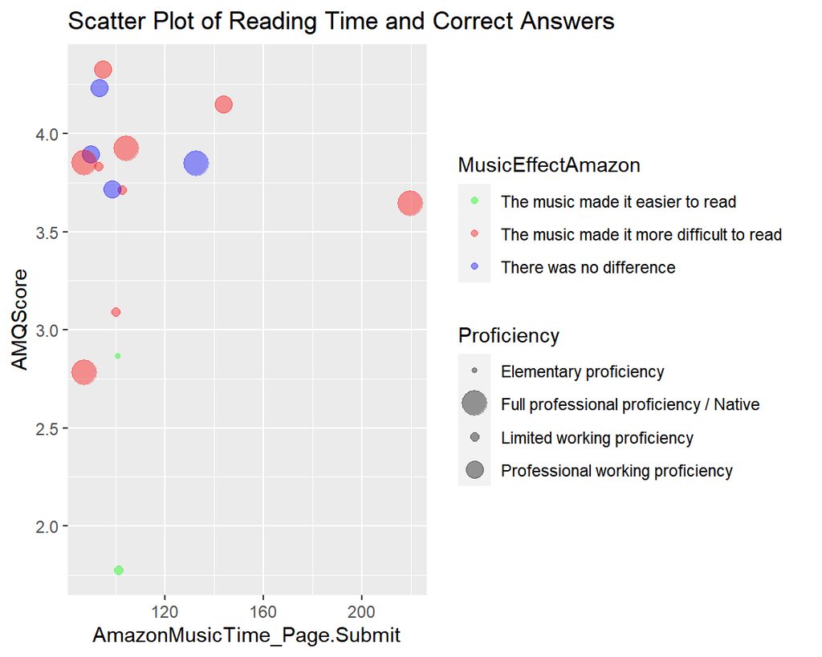

### Passage 2 with Music

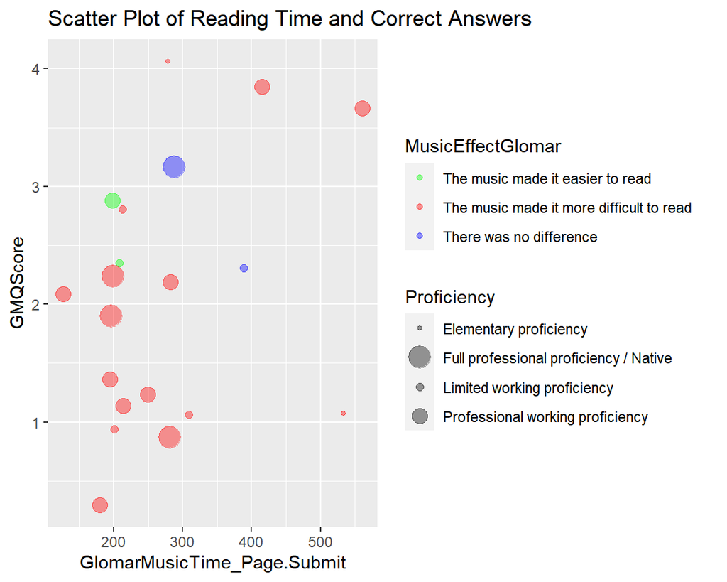

### Passage 1 without Music

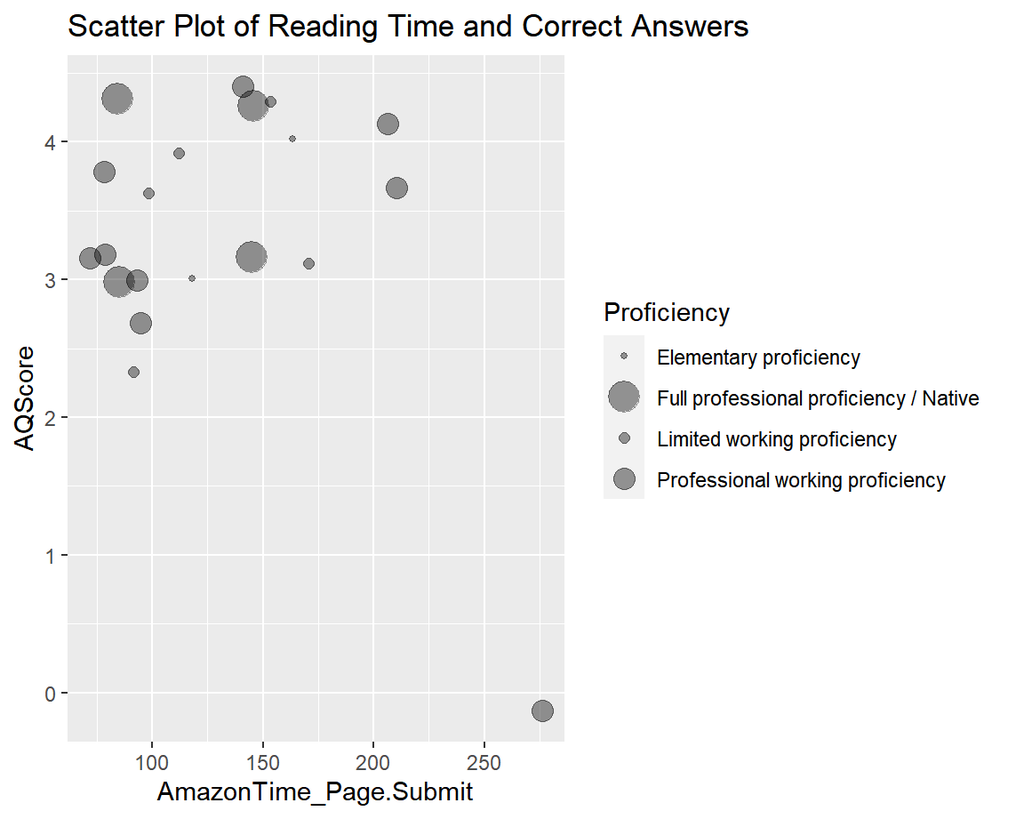

### Passage 2 without Music

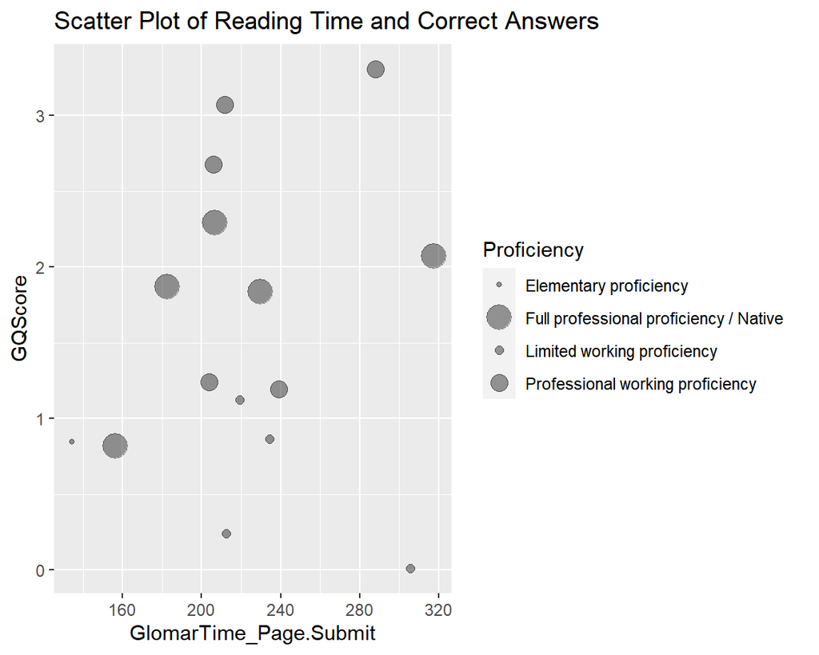

In analyzing the impact of background music on participants’ performance across both difficult and easy passages, distinct trends and perceptions emerged. For the challenging passage, a majority of participants found that music posed a difficulty, correlating with a lower accuracy in answering questions. Interestingly, a minority perceived music as making the task easier or having no effect, and this group achieved higher scores than the majority. Without music, the average time spent was lower compared to the condition with music. However, the number of individuals answering more questions correctly was comparable between the two conditions.

# Accuracy & Habit

### Passage 1

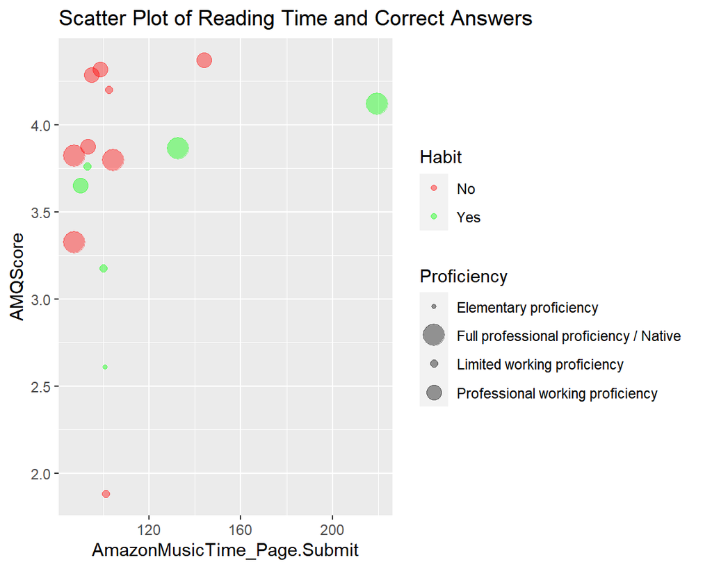

### Passage 2

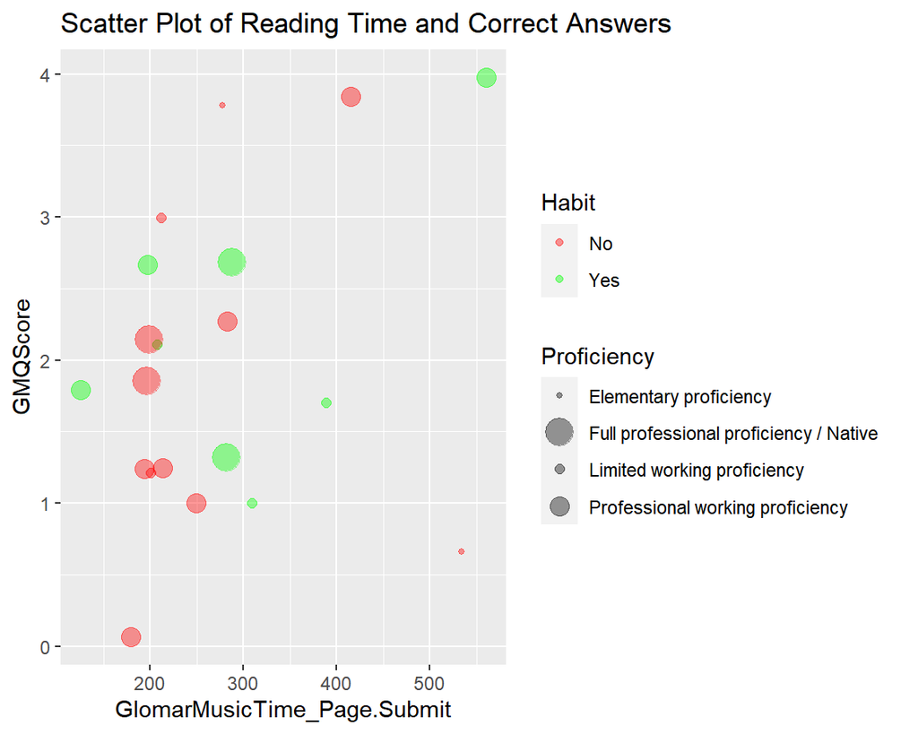

In the examination of the correlation between participants’ self-reported proficiency levels in English, their habitual engagement with music, and their performance on passages of different difficulty levels, intriguing patterns emerged.

For the initial, relatively straightforward passage, individuals across all proficiency levels, regardless of their customary music-listening practices, demonstrated commendable performance. This suggests that the simplicity of the passage might have mitigated the influence of both language proficiency and music habits.

In summary, akin to findings in studies on background music and reading times, our results reveal nuanced dynamics in the interplay of self-perceived proficiency, music-listening behaviors, and task performance, specifically within the realm of language challenges. This underscores the need for further exploration into the multifaceted variables that shape performance across varying linguistic complexities.

# Conclusion

### Violin plots representing the time taken to read both passages with and without music

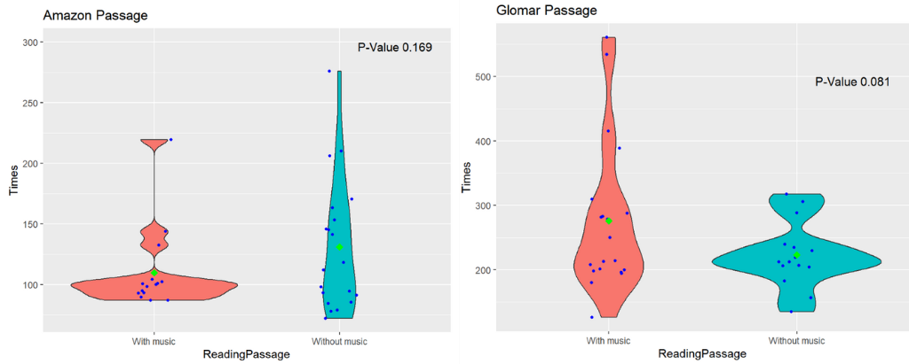

### Scatterplots representing how the accuracy was affected by music

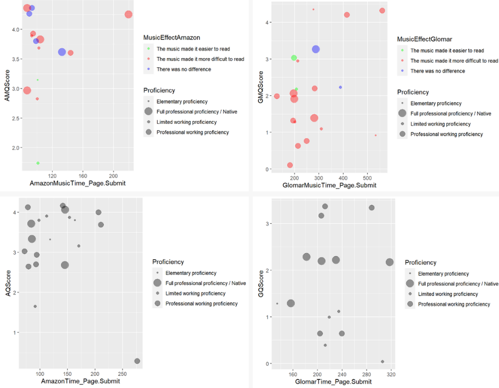

### Scatterplots representing how habit and proficiency levels are related

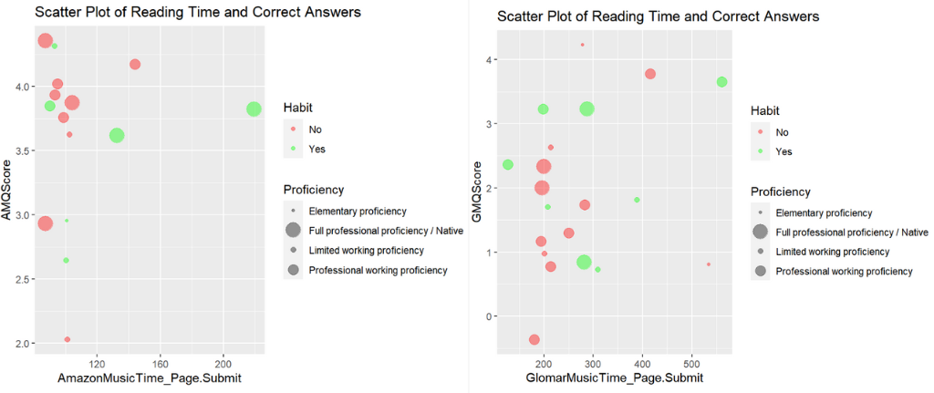

### Limitations

Given our deliberate selection and control of the music participants listened to during the experiment, it’s important to note that our findings may not be extrapolated to assert that all other genres of music would yield similar effects on reading time and accuracy. The primary aim of our research is not to discern the effectiveness of specific music genres in tasks requiring a high level of concentration. Instead, our focus lies in investigating whether the mere presence or absence of music significantly influences the speed and accuracy of information reception.

To maintain a broad perspective and steer clear of delving deeply into specific music categories, we opted for a selection of more “catchy” and popular songs. This choice allows us to explore the overarching impact of music presence without getting entangled in the nuances of particular genres.

# Background

### Literature Study

Our experiment draws inspiration from Teresa Lesiuk’s notable study, “The Effect of Music Listening on Work Performance.” Lesiuk’s investigation involved monitoring the mood, work quality, and time-on-task of 56 IT developers over a five-week period, allowing participants to choose their music during regular work activities.

In contrast, our approach involved a more controlled selection of music for our subjects. The rationale behind this decision was to expose all participants to the same auditory stimuli, given the limitations of Qualtrics in automatically playing individualized music choices. Notably, our experiment features a more diverse demographic, and the tasks assigned to our subjects exhibit clear distinctions in complexity. This deliberate variation allows us to discern whether music consistently influences performance across tasks demanding different levels of concentration.

Furthermore, Lesiuk’s findings highlighted individual differences in responses to music at the beginning of her experiment. To delve deeper into this aspect, we sought to investigate whether individuals’ habits of listening to music during work play a role in their responsiveness. This consideration prompted us to inquire about our subjects’ habits regarding music consumption, providing a nuanced perspective on the potential interplay between music habits and task performance.

### Sources

Lesiuk, T. (2005). The effect of music listening on work performance. Psychology of Music, 33(2), 173-191. https://doi.org/10.1177/0305735605050650

Mori, F. & Naghsh, F.A. & Tezuka, Taro. (2014). The effect of music on the level of mental concentration and its temporal change. CSEDU 2014 - Proceedings of the 6th International Conference on Computer Supported Education. 1. 34-42

Goltz F, Sadakata M. Do you listen to music while studying? A portrait of how people use music to optimize their cognitive performance. Acta Psychol (Amst). 2021 Oct;220:103417. doi: 10.1016/j.actpsy.2021.103417. Epub 2021 Sep 20. PMID: 34555564.